# UMAP

# Biblioteca `UMAP`

Vamos usar o conjunto de dados `Iris` para exemplificar o uso do algoritmo `UMAP`.

```r
head(iris, 3)
```

|  | Sepal.Length | Sepal.Width | Petal.Length | Petal.Width | Species |
| --- | --- | --- | --- | --- | --- |
| 1 | 5.1 | 3.5 | 1.4 | 0.2 | setosa |
| 2 | 4.9 | 3.0 | 1.4 | 0.2 | setosa |
| 3 | 4.7 | 3.2 | 1.3 | 0.2 | setosa |

Separando os dados em variáveis de treino e variável alvo.

```r
iris.data = iris[, grep("Sepal|Petal", colnames(iris))]
iris.labels = iris[, "Species"]
```

Importando a biblioteca e aplicando `UMAP` no conjunto `Iris`.

```r
library(umap)
iris.umap = umap(iris.data)
```

Visualizando o objeto obtido.

```r
iris.umap
```

```
## umap embedding of 150 items in 2 dimensions
## object components: layout, data, knn, config
```

Visualizando o conjunto de dados no espaço de dimensão menor.

```r
head(iris.umap$layout, 3)
```

```
##          [,1]     [,2]
## [1,] 15.04246 1.477186
## [2,] 16.99191 1.840291
## [3,] 16.77157 2.378725
```

Plotando o gráfico:

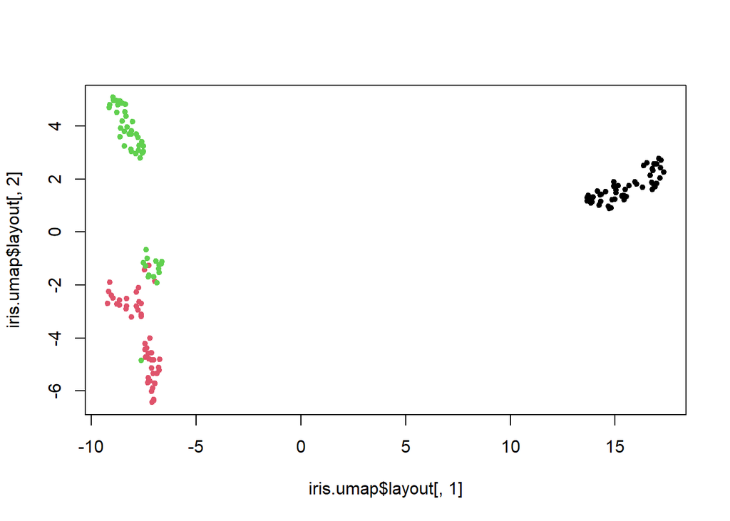

```r
plot(iris.umap$layout[,1], iris.umap$layout[,2],
     col=iris.labels,
     pch=20)
```

# Biblioteca `uwot`.

```r
library(uwot)
# vendo detalhes da implementação do algoritmo
#?umap


# Non-numeric columns are ignored, so in a lot of cases you can pass a data
# frame directly to umap
iris_umap <- umap(iris, n_neighbors = 50, learning_rate = 0.5, init = "random")
```

Plotando gráfico.

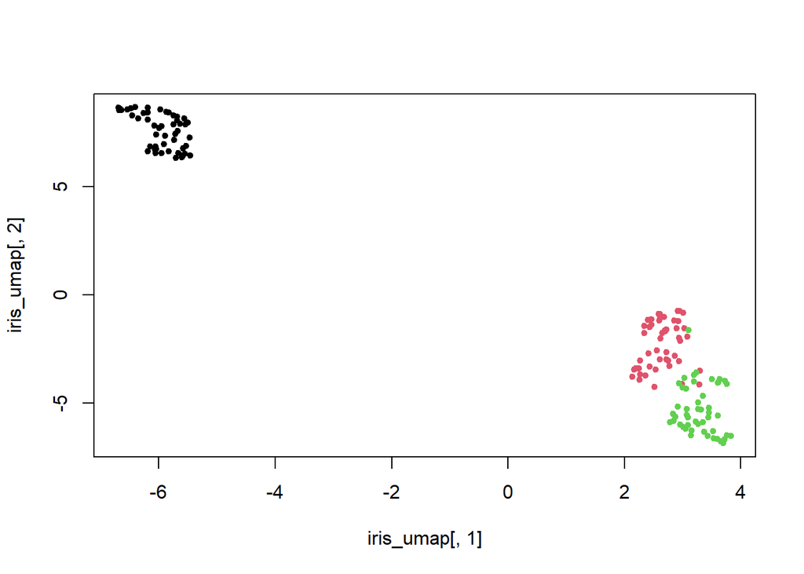

```r
plot(iris_umap[, 1], iris_umap[, 2],
     col=iris.labels,
     pch=20)
```

Carregando algumas bibliotecas que serão usadas a seguir.

```r
# Carregando o conjunto MNIST
library(readr)
library(dplyr)
```

Carregando o conjunto de dados `MNIST`.

```r
mnist <- read_csv("https://pjreddie.com/media/files/mnist_train.csv", col_names = FALSE)
```

Usar uma pré redução de dimensionalidade para conjuntos de dados com muitas variáveis não é necessário mas pode acelerar o tempo do algoritmo. Para isso pode-se usar `PCA` primeiramente para selecionar 50 variáveis e então aplicar `UMAP` isto pode ser feito diretamente com o comando a seguir:

```r
mnist_umap <- umap(mnist, pca = 50)
```

Plotando o gráfico.

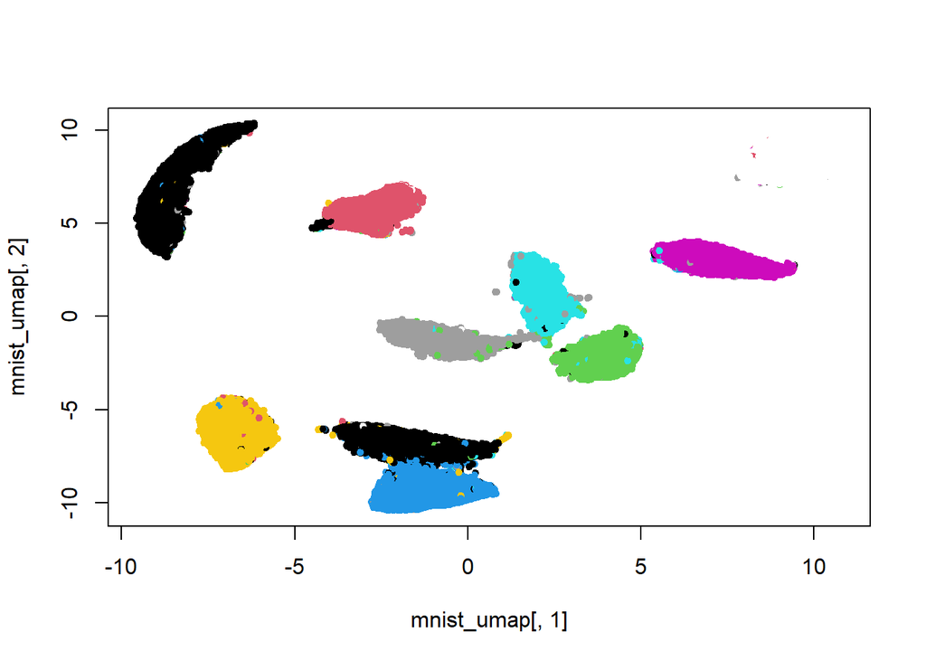

```r
mnist_umap <- cbind(mnist_umap, mnist[, 1])

plot(mnist_umap[, 1], mnist_umap[, 2],
     col = mnist_umap[,3],
     pch=20)
```

Podemos obter uma descrição da criação do algoritmo usanto `verbose = TRUE`.

```r
mnist_umap <- umap(mnist,
                   n_neighbors=15,
                   min_dist=0.001,
                   verbose=TRUE)
```

Instanciando um objeto `UMAP` com métrica diferente.

```r
# Usando uma métrica diferente
mnist_umap_cosine <- umap(mnist,
                          n_neighbors = 15,
                          metric = "cosine",
                          min_dist = 0.001,
                          verbose = TRUE)
```

Plotando gráfico.

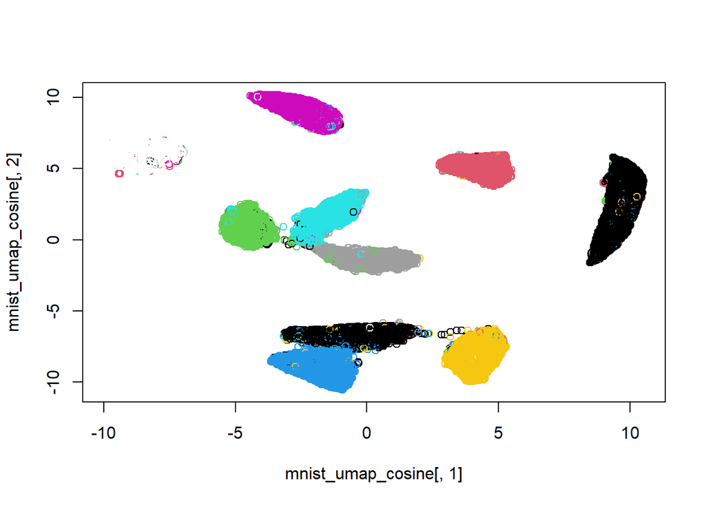

```r
mnist_umap_cosine <- cbind(mnist_umap_cosine, mnist[, 1])
plot(mnist_umap_cosine[, 1], mnist_umap_cosine[, 2], col=mnist_umap_cosine[, 3])
```

Se o interesse for apenas em visualização pode-se usar `fast_sgd = TRUE` para obter uma otimização mais rápida ao usar `Stochastic Gradient Descent`.

```r
mnist_umap_fast_sgd <- umap(mnist,
                            n_neighbors = 15,
                            metric = "cosine",
                            min_dist = 0.001,
                            verbose = TRUE,
                            fast_sgd = TRUE)
```

Plotando gráfico.

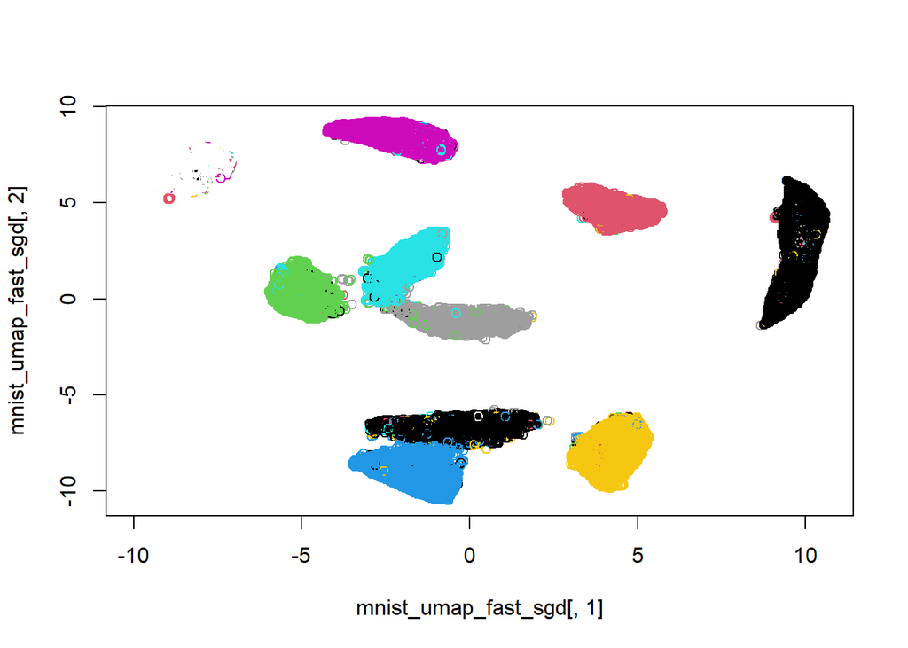

```r
mnist_umap_fast_sgd <- cbind(mnist_umap_fast_sgd, mnist[, 1])

plot(mnist_umap_fast_sgd[, 1], mnist_umap_fast_sgd[, 2],
     col=mnist_umap_fast_sgd[, 3])
```

Pode-se fazer redução de dimensão supervisionada.

```r
mnist_umap_s <- umap(mnist,
                     n_neighbors = 15,
                     min_dist = 0.001,
                     verbose = TRUE,
                     y = mnist$Label,
                     target_weight = 0.5)
```

Plotando gráfico.

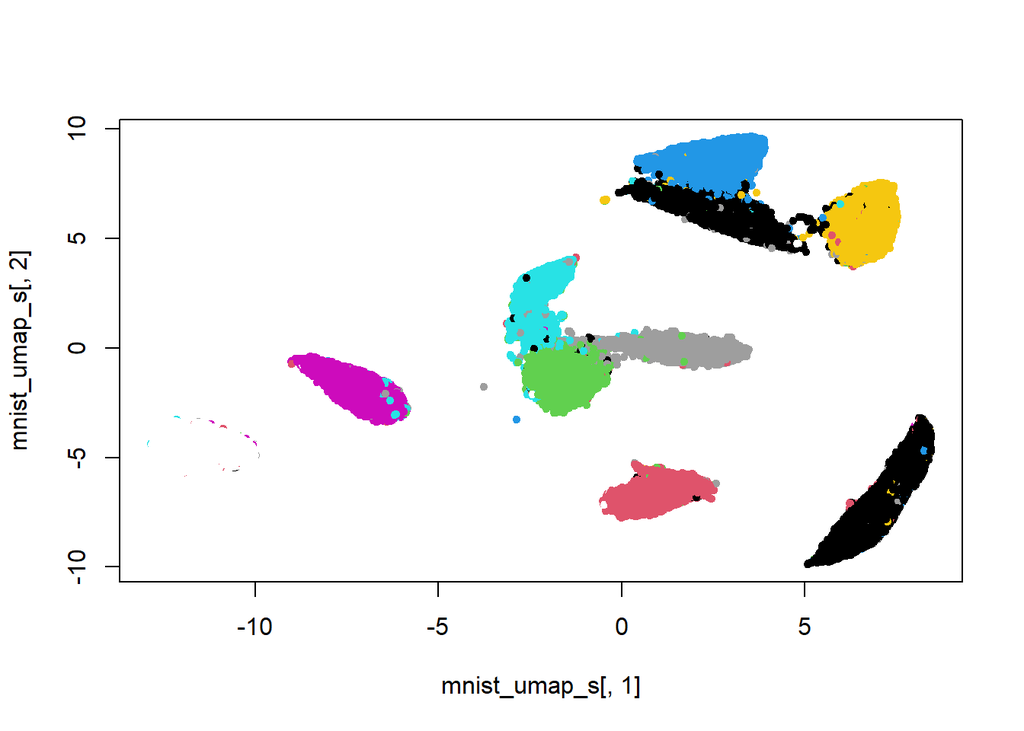

```r
mnist_umap_s <- cbind(mnist_umap_s, mnist[, 1])

plot(mnist_umap_s[, 1], mnist_umap_s[, 2],
     col=mnist_umap_s[, 3],
     pch=20)
```

Adicionando novos pontos a um espaço projetado. Vamos dividir os dados em treino e teste.

```r
mnist_train <- mnist[1:60000, ]
mnist_test <- mnist[60001:70000, ]
```

Devemos usar `ret_model = TRUE` para retornar dado extra contendo as coordenadas do treino no objeto `mnist_train_umap$embedding`

Treina-se o modelo com `mnist_train_umap <- umap(mnist_train, ret_model = TRUE)` e depois usa-se `mnist_test_umap <- umap_transform(mnist_test, mnist_train_umap$embedding)` para os dados de teste.

Outra coisa possível é salvar os dados dos vizinhos mais próximos para acelerar novos treinos do algoritmo. Para isto deve-se usar `ret_nn = TRUE` e as coordenadas ficam salvas no objeto `mnist_nn$nn`.

```r
mnist_nn <- umap(mnist, ret_nn = TRUE)
```

Vamos usar as coordenadas dos vizinhos mais próximos para retreinar o algoritmo com o comando a seguir:

```r
mnist_nn_spca <- umap(mnist, nn_method = mnist_nn$nn, init = "spca")
```

Pode-se usar `ret_nn = TRUE` and `ret_model = TRUE` ao mesmo tempo com o comando `umap(mnist, ret_extra = c("model", "nn"))`.

Também pode-se usar o parâmetro `fgraph` para criar o grafo usando matriz esparça com o comando `umap(mnist, ret_extra = c("fgraph"))`.